# Lojistik Regresyon Analizi: Öğrenci Cinsiyet Tahmini

İbrahim Emin İpek

2025-12-21

# Giriş

Bu çalışmada, öğrenci sağlık ve yaşam tarzı verilerini kullanarak cinsiyet tahmini için lojistik regresyon analizi gerçekleştirilmiştir.

**Veri Seti:** 1000 öğrenciye ait 14 değişken  
**Bağımlı Değişken:** Cinsiyet (0: Kadın, 1: Erkek)  
**Bağımsız Değişkenler:** 12 farklı sağlık ve yaşam tarzı değişkeni

# Kütüphanelerin Yüklenmesi

```r
# Gerekli kütüphaneleri yükle
library(tidyverse)
library(modelr)
library(broom)
library(readxl)
library(corrplot)
library(ResourceSelection)
library(DescTools)
library(cvms)
library(ggplot2)
library(tibble)
library(pROC)
library(knitr)
library(kableExtra)
library(MASS)  # En son yükle (select() çakışmasını önlemek için)
```

# Veri Yükleme ve Ön İşleme

```r
# Veri setini yükle
ogrenci_data <- read_excel("duzenli_data.xlsx")

# Cinsiyet değişkenini faktör olarak tanımla
ogrenci_data$Cinsiyet <- factor(ogrenci_data$Cinsiyet,
                                 levels = c(0, 1),
                                 labels = c("Kadin", "Erkek"))

# Veri yapısı
str(ogrenci_data)
```

```
## tibble [1,000 × 14] (S3: tbl_df/tbl/data.frame)
##  $ Ogrenci_ID               : num [1:1000] 1 2 3 4 5 6 7 8 9 10 ...
##  $ Yas                      : num [1:1000] 24 21 22 24 20 22 22 24 19 20 ...
##  $ Cinsiyet                 : Factor w/ 2 levels "Kadin","Erkek": 2 1 2 2 2 2 1 1 1 2 ...
##  $ Nabiz                    : num [1:1000] 50.7 57.9 59.3 76.8 68.3 ...
##  $ Kan_Basinci_Sistolik     : num [1:1000] 122 111 109 125 108 ...
##  $ Kan_Basinci_Diyastolik   : num [1:1000] 84.4 75.7 83.8 78.1 80.7 ...
##  $ Stress_Seviyesi_Biosensor: num [1:1000] 3.14 3.7 6.79 6.41 7.26 ...
##  $ Stress_Seviyesi_Bildirim : num [1:1000] 9.03 5.82 5.89 6.88 4.48 ...
##  $ Fiziksel_Aktivite        : num [1:1000] 3 2 1 3 2 2 2 1 2 2 ...
##  $ Uyku_Kalitesi            : num [1:1000] 2 3 2 1 1 3 2 3 2 2 ...
##  $ Ruh_Hali                 : num [1:1000] 3 1 3 3 3 3 3 2 2 3 ...
##  $ Ders_Saatleri            : num [1:1000] 34.52 16.76 44.2 21.78 8.96 ...
##  $ Proje_Saatleri           : num [1:1000] 16.8 15.8 25.7 20.8 15.2 ...
##  $ Saglik_Riski_Seviyesi    : num [1:1000] 2 2 2 3 2 2 2 1 2 2 ...
```

## Özet İstatistikler

```r
# Özet tablo
summary(ogrenci_data) %>%
  kable(caption = "Veri Seti Özet İstatistikleri") %>%
  kable_styling(bootstrap_options = c("striped", "hover", "condensed"))
```

Veri Seti Özet İstatistikleri

|  | Ogrenci_ID | Yas | Cinsiyet | Nabiz | Kan_Basinci_Sistolik | Kan_Basinci_Diyastolik | Stress_Seviyesi_Biosensor | Stress_Seviyesi_Bildirim | Fiziksel_Aktivite | Uyku_Kalitesi | Ruh_Hali | Ders_Saatleri | Proje_Saatleri | Saglik_Riski_Seviyesi |
| --- | --- | --- | --- | --- | --- | --- | --- | --- | --- | --- | --- | --- | --- | --- |
|  | Min. : 1.0 | Min. :18.00 | Kadin:481 | Min. :50.00 | Min. : 90.0 | Min. : 60.00 | Min. :1.008 | Min. :1.002 | Min. :1.000 | Min. :1.000 | Min. :1.000 | Min. : 5.00 | Min. : 0.00 | Min. :1.000 |
|  | 1st Qu.: 250.8 | 1st Qu.:19.00 | Erkek:519 | 1st Qu.:63.35 | 1st Qu.:109.4 | 1st Qu.: 73.12 | 1st Qu.:3.271 | 1st Qu.:3.172 | 1st Qu.:1.000 | 1st Qu.:2.000 | 1st Qu.:2.000 | 1st Qu.:23.26 | 1st Qu.:11.57 | 1st Qu.:2.000 |
|  | Median : 500.5 | Median :21.00 | NA | Median :70.33 | Median :120.1 | Median : 79.65 | Median :5.369 | Median :5.235 | Median :2.000 | Median :2.000 | Median :2.000 | Median :30.43 | Median :14.77 | Median :2.000 |
|  | Mean : 500.5 | Mean :20.96 | NA | Mean :70.10 | Mean :119.8 | Mean : 79.85 | Mean :5.484 | Mean :5.362 | Mean :1.905 | Mean :2.263 | Mean :2.213 | Mean :30.23 | Mean :14.89 | Mean :1.948 |
|  | 3rd Qu.: 750.2 | 3rd Qu.:23.00 | NA | 3rd Qu.:76.43 | 3rd Qu.:130.4 | 3rd Qu.: 86.54 | 3rd Qu.:7.674 | 3rd Qu.:7.471 | 3rd Qu.:2.000 | 3rd Qu.:3.000 | 3rd Qu.:3.000 | 3rd Qu.:37.25 | 3rd Qu.:18.16 | 3rd Qu.:2.000 |
|  | Max. :1000.0 | Max. :24.00 | NA | Max. :99.65 | Max. :165.9 | Max. :107.66 | Max. :9.994 | Max. :9.964 | Max. :3.000 | Max. :3.000 | Max. :3.000 | Max. :60.00 | Max. :32.72 | Max. :3.000 |

# Keşifsel Veri Analizi

## Cinsiyet Dağılımı

```r
# Cinsiyet dağılımı
table(ogrenci_data$Cinsiyet) %>%
  prop.table() %>%
  round(3) %>%
  kable(col.names = c("Cinsiyet", "Oran")) %>%
  kable_styling(bootstrap_options = "striped", full_width = FALSE)
```

| Cinsiyet | Oran |
| --- | --- |
| Kadin | 0.481 |
| Erkek | 0.519 |

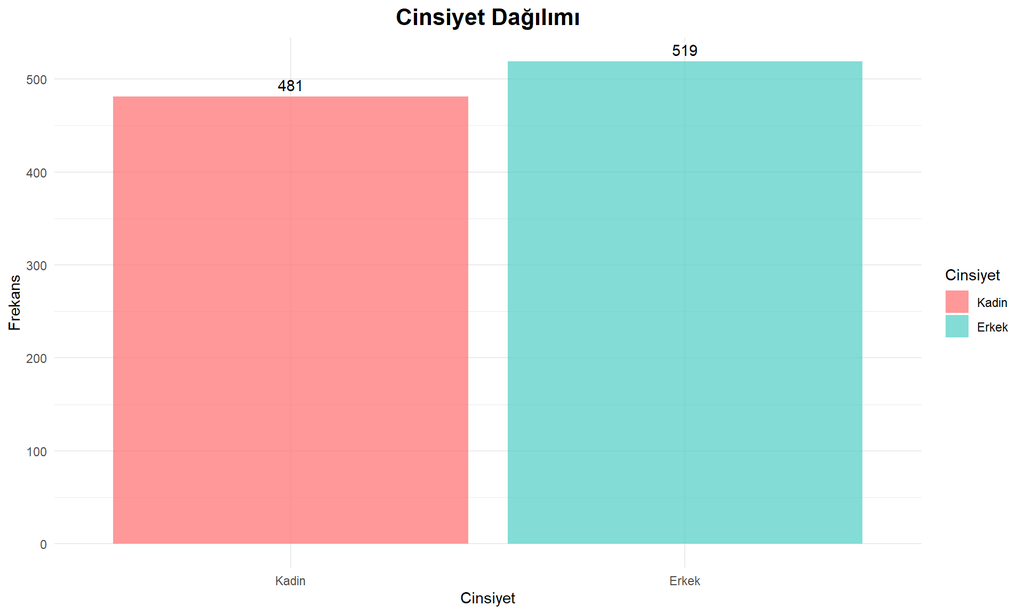

```r
# Görselleştirme
ggplot(ogrenci_data, aes(x = Cinsiyet, fill = Cinsiyet)) +
  geom_bar(alpha = 0.7) +
  geom_text(stat = 'count', aes(label = ..count..), vjust = -0.5) +
  scale_fill_manual(values = c("Kadin" = "#FF6B6B", "Erkek" = "#4ECDC4")) +
  theme_minimal() +
  labs(title = "Cinsiyet Dağılımı",
       x = "Cinsiyet",
       y = "Frekans") +
  theme(plot.title = element_text(hjust = 0.5, size = 16, face = "bold"))
```

## Korelasyon Analizi

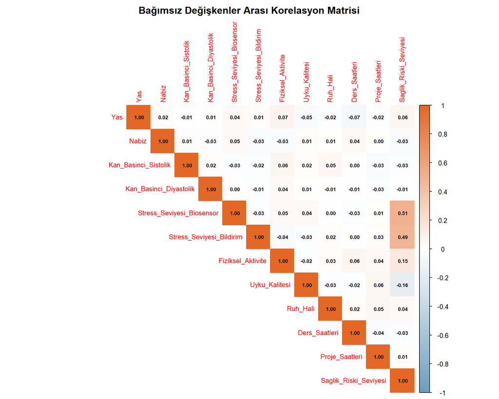

```r
# Bağımsız değişkenler için korelasyon matrisi
bagimli_degiskenler <- ogrenci_data %>%
  dplyr::select(-Cinsiyet, -Ogrenci_ID)

# Korelasyon matrisi
korelasyon <- cor(bagimli_degiskenler)

# Görselleştirme
corrplot(korelasyon,
         method = "color",
         type = "upper",
         addCoef.col = "black",
         tl.cex = 0.8,
         number.cex = 0.6,
         title = "Bağımsız Değişkenler Arası Korelasyon Matrisi",
         mar = c(0, 0, 2, 0),
         col = colorRampPalette(c("#6D9EC1", "white", "#E46726"))(200))
```

```r
# VIF hesabı için korelasyon matrisinin tersi
invkor <- solve(korelasyon)

# Çoklu bağlantı kontrolü
diag(invkor) %>%
  as.data.frame() %>%
  setNames("VIF") %>%
  rownames_to_column("Degisken") %>%
  arrange(desc(VIF)) %>%
  kable(caption = "VIF Değerleri (Çoklu Bağlantı Kontrolü)", digits = 2) %>%
  kable_styling(bootstrap_options = c("striped", "hover"))
```

VIF Değerleri (Çoklu Bağlantı Kontrolü)

| Degisken | VIF |
| --- | --- |
| Saglik_Riski_Seviyesi | 2.28 |
| Stress_Seviyesi_Biosensor | 1.63 |
| Stress_Seviyesi_Bildirim | 1.57 |
| Fiziksel_Aktivite | 1.07 |
| Uyku_Kalitesi | 1.07 |
| Yas | 1.02 |
| Ders_Saatleri | 1.02 |
| Proje_Saatleri | 1.01 |
| Kan_Basinci_Sistolik | 1.01 |
| Nabiz | 1.01 |
| Ruh_Hali | 1.01 |
| Kan_Basinci_Diyastolik | 1.00 |

**Not:** VIF değerleri >10 ise ciddi çoklu bağlantı problemi vardır.

# Model 1: Önerilen 6 Değişkenli Model

## Model Tanımı

En yüksek performansı veren model aşağıdaki 6 değişkeni içermektedir:

- Yas
- Nabiz
- Stress_Seviyesi_Biosensor
- Fiziksel_Aktivite
- Ruh_Hali
- Proje_Saatleri

```r
model1 <- glm(Cinsiyet ~ Yas + Nabiz + Stress_Seviyesi_Biosensor +
                         Fiziksel_Aktivite + Ruh_Hali + Proje_Saatleri,
              family = "binomial",
              data = ogrenci_data)

# Model özeti
summary(model1)
```

```
##
## Call:
## glm(formula = Cinsiyet ~ Yas + Nabiz + Stress_Seviyesi_Biosensor +
##     Fiziksel_Aktivite + Ruh_Hali + Proje_Saatleri, family = "binomial",
##     data = ogrenci_data)
##
## Coefficients:
##                            Estimate Std. Error z value Pr(>|z|)
## (Intercept)               -0.214538   0.868395  -0.247   0.8049
## Yas                        0.016172   0.031859   0.508   0.6117
## Nabiz                      0.007672   0.006687   1.147   0.2513
## Stress_Seviyesi_Biosensor -0.043117   0.024587  -1.754   0.0795 .
## Fiziksel_Aktivite         -0.101386   0.090362  -1.122   0.2619
## Ruh_Hali                  -0.116062   0.086784  -1.337   0.1811
## Proje_Saatleri             0.006769   0.013037   0.519   0.6036
## ---
## Signif. codes:  0 '***' 0.001 '**' 0.01 '*' 0.05 '.' 0.1 ' ' 1
##
## (Dispersion parameter for binomial family taken to be 1)
##
##     Null deviance: 1384.9  on 999  degrees of freedom
## Residual deviance: 1376.9  on 993  degrees of freedom
## AIC: 1390.9
##
## Number of Fisher Scoring iterations: 3
```

## Model Anlamlılık Testleri

### Omnibus Tests of Model Coefficients

```r
kikare1 <- model1$null.deviance - model1$deviance
df1 <- model1$df.null - model1$df.residual
kikare1_p <- 1 - pchisq(kikare1, df1)

omnibus_df <- data.frame(
  Test = "Model Katsayıları",
  `Ki-kare` = round(kikare1, 4),
  df = df1,
  `P-degeri` = round(kikare1_p, 4),
  check.names = FALSE
)

omnibus_df %>%
  kable(caption = "Omnibus Tests of Model Coefficients") %>%
  kable_styling(bootstrap_options = "striped", full_width = FALSE)
```

Omnibus Tests of Model Coefficients

| Test | Ki-kare | df | P-degeri |
| --- | --- | --- | --- |
| Model Katsayıları | 7.9024 | 6 | 0.2453 |

```r
if(kikare1_p < 0.05) {
  cat("\n**Yorum:** Eklenen değişkenler modele ANLAMLI katkı sağlamaktadır (p<0.05)\n")
} else {
  cat("\n**Yorum:** Eklenen değişkenler modele anlamlı katkı sağlamamaktadır (p>=0.05)\n")
}
```

```
##
## **Yorum:** Eklenen değişkenler modele anlamlı katkı sağlamamaktadır (p>=0.05)
```

### Hosmer-Lemeshow Uyum İyiliği Testi

```r
hoslem1 <- hoslem.test(model1$y, fitted(model1))

hoslem_df <- data.frame(
  Test = "Hosmer-Lemeshow",
  `Ki-kare` = round(hoslem1$statistic, 4),
  df = hoslem1$parameter,
  `P-degeri` = round(hoslem1$p.value, 4),
  check.names = FALSE
)

hoslem_df %>%
  kable(caption = "Hosmer-Lemeshow Uyum İyiliği Testi") %>%
  kable_styling(bootstrap_options = "striped", full_width = FALSE)
```

Hosmer-Lemeshow Uyum İyiliği Testi

|  | Test | Ki-kare | df | P-degeri |
| --- | --- | --- | --- | --- |
| X-squared | Hosmer-Lemeshow | 8.3007 | 8 | 0.4047 |

```r
if(hoslem1$p.value > 0.05) {
  cat("\n**Yorum:** Model veriye UYUMLUDUR (p>0.05)\n")
} else {
  cat("\n**Yorum:** Model veriye uyumlu DEĞİLDİR (p<=0.05)\n")
}
```

```
##
## **Yorum:** Model veriye UYUMLUDUR (p>0.05)
```

## Model Özet İstatistikleri

### Pseudo R-kare Değerleri

```r
r2_values1 <- PseudoR2(model1, which = c("CoxSnell", "Nagelkerke", "McFadden"))

r2_df1 <- data.frame(
  Metrik = names(r2_values1),
  Deger = round(r2_values1, 4)
)

r2_df1 %>%
  kable(caption = "Pseudo R-kare Değerleri - Model 1") %>%
  kable_styling(bootstrap_options = "striped", full_width = FALSE)
```

Pseudo R-kare Değerleri - Model 1

|  | Metrik | Deger |
| --- | --- | --- |
| CoxSnell | CoxSnell | 0.0079 |
| Nagelkerke | Nagelkerke | 0.0105 |
| McFadden | McFadden | 0.0057 |

### Odds Ratio ve Güven Aralıkları

```r
odds_ratio1 <- exp(coef(model1))
conf_intervals1 <- exp(confint.default(model1, level = 0.95))
or_table1 <- cbind(
  `Odds Ratio` = odds_ratio1,
  conf_intervals1
)

or_table1 %>%
  as.data.frame() %>%
  rownames_to_column("Degisken") %>%
  kable(caption = "Odds Ratio ve %95 Güven Aralıkları - Model 1",
        digits = 4) %>%
  kable_styling(bootstrap_options = c("striped", "hover"))
```

Odds Ratio ve %95 Güven Aralıkları - Model 1

| Degisken | Odds Ratio | 2.5 % | 97.5 % |
| --- | --- | --- | --- |
| (Intercept) | 0.8069 | 0.1471 | 4.4259 |
| Yas | 1.0163 | 0.9548 | 1.0818 |
| Nabiz | 1.0077 | 0.9946 | 1.0210 |
| Stress_Seviyesi_Biosensor | 0.9578 | 0.9127 | 1.0051 |
| Fiziksel_Aktivite | 0.9036 | 0.7569 | 1.0787 |
| Ruh_Hali | 0.8904 | 0.7511 | 1.0555 |
| Proje_Saatleri | 1.0068 | 0.9814 | 1.0328 |

**Odds Ratio Yorumu:** - OR > 1: Değişken arttıkça erkek olma olasılığı artar - OR < 1: Değişken arttıkça kadın olma olasılığı artar - OR = 1: Değişkenin etkisi yok

## Sınıflandırma Performansı

```r
# Tahminler
cinsiyet_pred1 <- fitted(model1)
cinsiyet_fac1 <- ifelse(cinsiyet_pred1 > 0.5, "Erkek", "Kadin")

# Confusion Matrix
sinif_tab1 <- table(Gercek = ogrenci_data$Cinsiyet,
                    Tahmin = cinsiyet_fac1)

sinif_tab1 %>%
  kable(caption = "Sınıflandırma Tablosu - Model 1 (Cut-off: 0.5)") %>%
  kable_styling(bootstrap_options = "striped", full_width = FALSE)
```

Sınıflandırma Tablosu - Model 1 (Cut-off: 0.5)

|  | Erkek | Kadin |
| --- | --- | --- |
| Kadin | 301 | 180 |
| Erkek | 359 | 160 |

```r
# Doğruluk oranı
accuracy1 <- sum(diag(sinif_tab1)) / sum(sinif_tab1)
cat(sprintf("\n**Toplam Doğru Sınıflandırma Oranı:** %.2f%%\n", accuracy1 * 100))
```

[output not shown]

```r
# Hassasiyet ve özgüllük hesapla
sensitivity1 <- sinif_tab1[2,2] / sum(sinif_tab1[2,])
specificity1 <- sinif_tab1[1,1] / sum(sinif_tab1[1,])

metrics_df1 <- data.frame(
  Metrik = c("Accuracy", "Sensitivity (Erkek)", "Specificity (Kadın)"),
  Deger = c(accuracy1, sensitivity1, specificity1)
)

metrics_df1 %>%
  mutate(Yuzde = paste0(round(Deger * 100, 2), "%")) %>%
  dplyr::select(Metrik, Yuzde) %>%
  kable(caption = "Model 1 Performans Metrikleri") %>%
  kable_styling(bootstrap_options = "striped", full_width = FALSE)
```

Model 1 Performans Metrikleri

[output not shown]

### Sınıflandırma Matrisi Görselleştirmesi

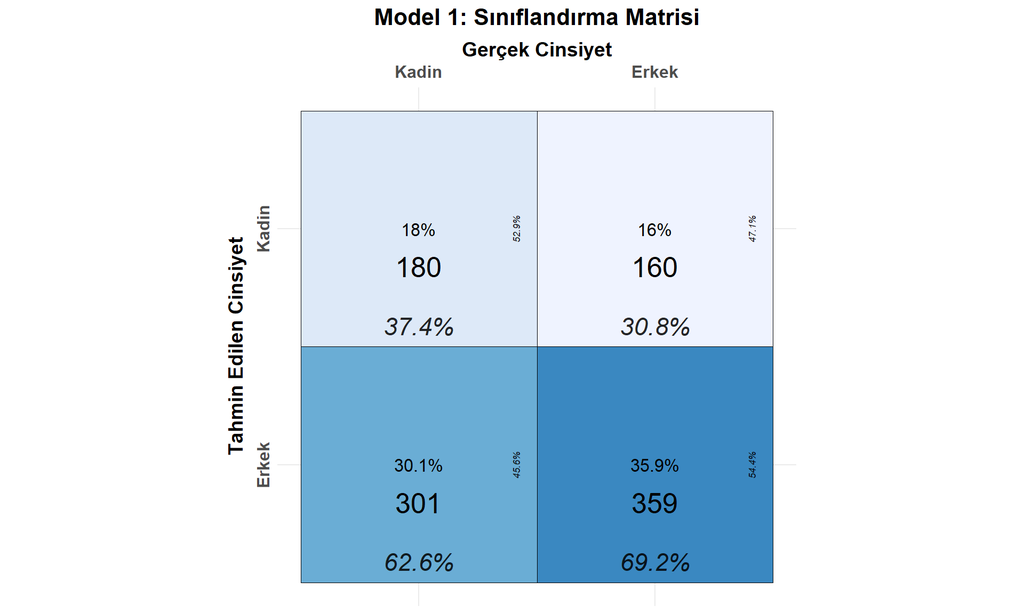

```r
datatib1 <- tibble("target" = ogrenci_data$Cinsiyet,
                   "prediction" = cinsiyet_fac1)
cfm1 <- tidy(table(datatib1))

plot_confusion_matrix(cfm1,
                      target_col = "target",
                      prediction_col = "prediction",
                      counts_col = "n",
                      add_normalized = TRUE,
                      add_row_percentages = TRUE,
                      font_col_percentages = font(size = 6),
                      font_counts = font(size = 7),
                      tile_border_color = "black") +
  ggtitle("Model 1: Sınıflandırma Matrisi") +
  xlab("Gerçek Cinsiyet") +
  ylab("Tahmin Edilen Cinsiyet") +
  theme(axis.text = element_text(size = 12, face = "bold"),
        axis.title = element_text(size = 14, face = "bold"),
        plot.title = element_text(size = 16, face = "bold", hjust = 0.5))
```

# Model 2: 4 Değişkenli Model

## Model Tanımı

En yüksek AUC skoruna sahip 4 değişkenli model:

```r
model2 <- glm(Cinsiyet ~ Yas + Stress_Seviyesi_Biosensor +
                         Fiziksel_Aktivite + Ruh_Hali,
              family = "binomial",
              data = ogrenci_data)

summary(model2)
```

```
##
## Call:
## glm(formula = Cinsiyet ~ Yas + Stress_Seviyesi_Biosensor + Fiziksel_Aktivite +
##     Ruh_Hali, family = "binomial", data = ogrenci_data)
##
## Coefficients:
##                           Estimate Std. Error z value Pr(>|z|)
## (Intercept)                0.40413    0.71610   0.564   0.5725
## Yas                        0.01655    0.03182   0.520   0.6030
## Stress_Seviyesi_Biosensor -0.04164    0.02453  -1.697   0.0896 .
## Fiziksel_Aktivite         -0.10327    0.09019  -1.145   0.2522
## Ruh_Hali                  -0.11272    0.08658  -1.302   0.1929
## ---
## Signif. codes:  0 '***' 0.001 '**' 0.01 '*' 0.05 '.' 0.1 ' ' 1
##
## (Dispersion parameter for binomial family taken to be 1)
##
##     Null deviance: 1384.9  on 999  degrees of freedom
## Residual deviance: 1378.5  on 995  degrees of freedom
## AIC: 1388.5
##
## Number of Fisher Scoring iterations: 3
```

## Model 2 Performans Değerlendirmesi

```r
# Ki-kare testi
kikare2 <- model2$null.deviance - model2$deviance
df2 <- model2$df.null - model2$df.residual
kikare2_p <- 1 - pchisq(kikare2, df2)

# Hosmer-Lemeshow
hoslem2 <- hoslem.test(model2$y, fitted(model2))

# R-kare
r2_values2 <- PseudoR2(model2, which = c("CoxSnell", "Nagelkerke", "McFadden"))

# Sınıflandırma
cinsiyet_pred2 <- fitted(model2)
cinsiyet_fac2 <- ifelse(cinsiyet_pred2 > 0.5, "Erkek", "Kadin")
sinif_tab2 <- table(Gercek = ogrenci_data$Cinsiyet,
                    Tahmin = cinsiyet_fac2)
accuracy2 <- sum(diag(sinif_tab2)) / sum(sinif_tab2)

# Özet tablo
model2_summary <- data.frame(
  Metrik = c("Ki-kare (p-değeri)", "Hosmer-Lemeshow (p-değeri)",
             "Nagelkerke R²", "Accuracy"),
  Deger = c(
    sprintf("%.2f (p=%.3f)", kikare2, kikare2_p),
    sprintf("%.2f (p=%.3f)", hoslem2$statistic, hoslem2$p.value),
    sprintf("%.4f", r2_values2["Nagelkerke"]),
    sprintf("%.2f%%", accuracy2 * 100)
  )
)

model2_summary %>%
  kable(caption = "Model 2 Performans Özeti") %>%
  kable_styling(bootstrap_options = "striped", full_width = FALSE)
```

Model 2 Performans Özeti

| Metrik | Deger |
| --- | --- |
| Ki-kare (p-değeri) | 6.31 (p=0.177) |
| Hosmer-Lemeshow (p-değeri) | 5.48 (p=0.705) |
| Nagelkerke R² | 0.0084 |
| Accuracy | 46.40% |

# Model 3: 3 Değişkenli Model

## Model Tanımı

En basit model - Sadece 3 değişken ile en yüksek AUC:

```r
model3 <- glm(Cinsiyet ~ Yas + Stress_Seviyesi_Biosensor + Ruh_Hali,
              family = "binomial",
              data = ogrenci_data)

summary(model3)
```

```
##
## Call:
## glm(formula = Cinsiyet ~ Yas + Stress_Seviyesi_Biosensor + Ruh_Hali,
##     family = "binomial", data = ogrenci_data)
##
## Coefficients:
##                           Estimate Std. Error z value Pr(>|z|)
## (Intercept)                0.27412    0.70648   0.388   0.6980
## Yas                        0.01398    0.03171   0.441   0.6594
## Stress_Seviyesi_Biosensor -0.04279    0.02450  -1.747   0.0807 .
## Ruh_Hali                  -0.11571    0.08650  -1.338   0.1810
## ---
## Signif. codes:  0 '***' 0.001 '**' 0.01 '*' 0.05 '.' 0.1 ' ' 1
##
## (Dispersion parameter for binomial family taken to be 1)
##
##     Null deviance: 1384.9  on 999  degrees of freedom
## Residual deviance: 1379.9  on 996  degrees of freedom
## AIC: 1387.9
##
## Number of Fisher Scoring iterations: 3
```

## Model 3 Performans Değerlendirmesi

```r
# Performans metrikleri
kikare3 <- model3$null.deviance - model3$deviance
df3 <- model3$df.null - model3$df.residual
kikare3_p <- 1 - pchisq(kikare3, df3)

r2_values3 <- PseudoR2(model3, which = c("CoxSnell", "Nagelkerke", "McFadden"))

cinsiyet_pred3 <- fitted(model3)
cinsiyet_fac3 <- ifelse(cinsiyet_pred3 > 0.5, "Erkek", "Kadin")
sinif_tab3 <- table(Gercek = ogrenci_data$Cinsiyet,
                    Tahmin = cinsiyet_fac3)
accuracy3 <- sum(diag(sinif_tab3)) / sum(sinif_tab3)

# Odds Ratio
or_table3 <- exp(cbind(OR = coef(model3), confint.default(model3)))

or_table3 %>%
  as.data.frame() %>%
  rownames_to_column("Degisken") %>%
  kable(caption = "Model 3 - Odds Ratio ve Güven Aralıkları", digits = 4) %>%
  kable_styling(bootstrap_options = "striped", full_width = FALSE)
```

Model 3 - Odds Ratio ve Güven Aralıkları

| Degisken | OR | 2.5 % | 97.5 % |
| --- | --- | --- | --- |
| (Intercept) | 1.3154 | 0.3294 | 5.2530 |
| Yas | 1.0141 | 0.9530 | 1.0791 |
| Stress_Seviyesi_Biosensor | 0.9581 | 0.9132 | 1.0052 |
| Ruh_Hali | 0.8907 | 0.7518 | 1.0553 |

# Stepwise Değişken Seçimi

## Backward Elimination

```r
# Tüm değişkenlerle başla
full_model <- glm(Cinsiyet ~ Yas + Nabiz + Kan_Basinci_Sistolik +
                             Kan_Basinci_Diyastolik + Stress_Seviyesi_Biosensor +
                             Stress_Seviyesi_Bildirim + Fiziksel_Aktivite +
                             Uyku_Kalitesi + Ruh_Hali + Ders_Saatleri +
                             Proje_Saatleri + Saglik_Riski_Seviyesi,
                  family = "binomial",
                  data = ogrenci_data)

# Backward elimination
step_model <- step(full_model, direction = "backward", trace = 0)

summary(step_model)
```

```
##
## Call:
## glm(formula = Cinsiyet ~ Kan_Basinci_Sistolik + Kan_Basinci_Diyastolik +
##     Stress_Seviyesi_Biosensor + Uyku_Kalitesi, family = "binomial",
##     data = ogrenci_data)
##
## Coefficients:
##                            Estimate Std. Error z value Pr(>|z|)
## (Intercept)                0.704610   0.770730   0.914   0.3606
## Kan_Basinci_Sistolik      -0.007370   0.004380  -1.683   0.0925 .
## Kan_Basinci_Diyastolik     0.011186   0.006629   1.688   0.0915 .
## Stress_Seviyesi_Biosensor -0.041466   0.024613  -1.685   0.0920 .
## Uyku_Kalitesi             -0.181250   0.081693  -2.219   0.0265 *
## ---
## Signif. codes:  0 '***' 0.001 '**' 0.01 '*' 0.05 '.' 0.1 ' ' 1
##
## (Dispersion parameter for binomial family taken to be 1)
##
##     Null deviance: 1384.9  on 999  degrees of freedom
## Residual deviance: 1371.3  on 995  degrees of freedom
## AIC: 1381.3
##
## Number of Fisher Scoring iterations: 4
```

## Stepwise Model Performansı

```r
cinsiyet_pred_step <- fitted(step_model)
cinsiyet_fac_step <- ifelse(cinsiyet_pred_step > 0.5, "Erkek", "Kadin")
sinif_tab_step <- table(Gercek = ogrenci_data$Cinsiyet,
                        Tahmin = cinsiyet_fac_step)
accuracy_step <- sum(diag(sinif_tab_step)) / sum(sinif_tab_step)

cat(sprintf("Stepwise Model Accuracy: %.2f%%\n", accuracy_step * 100))
```

```
## Stepwise Model Accuracy: 44.30%
```

```r
cat(sprintf("Seçilen Değişken Sayısı: %d\n", length(coef(step_model)) - 1))
```

```
## Seçilen Değişken Sayısı: 4
```

# Model Karşılaştırması

## Performans Karşılaştırma Tablosu

```r
model_comparison <- data.frame(
  Model = c("Model 1 (6 değişken)",
            "Model 2 (4 değişken)",
            "Model 3 (3 değişken)",
            "Stepwise Model"),
  Degisken_Sayisi = c(6, 4, 3, length(coef(step_model)) - 1),
  Accuracy = c(accuracy1, accuracy2, accuracy3, accuracy_step),
  Cox_Snell_R2 = c(r2_values1["CoxSnell"],
                   r2_values2["CoxSnell"],
                   r2_values3["CoxSnell"],
                   PseudoR2(step_model)["CoxSnell"]),
  Nagelkerke_R2 = c(r2_values1["Nagelkerke"],
                    r2_values2["Nagelkerke"],
                    r2_values3["Nagelkerke"],
                    PseudoR2(step_model)["Nagelkerke"]),
  AIC = c(AIC(model1), AIC(model2), AIC(model3), AIC(step_model)),
  BIC = c(BIC(model1), BIC(model2), BIC(model3), BIC(step_model))
)

model_comparison %>%
  mutate(
    Accuracy = paste0(round(Accuracy * 100, 2), "%"),
    Cox_Snell_R2 = round(Cox_Snell_R2, 4),
    Nagelkerke_R2 = round(Nagelkerke_R2, 4),
    AIC = round(AIC, 2),
    BIC = round(BIC, 2)
  ) %>%
  kable(caption = "Model Karşılaştırma Tablosu") %>%
  kable_styling(bootstrap_options = c("striped", "hover")) %>%
  row_spec(1, bold = TRUE, background = "#d4edda")
```

Model Karşılaştırma Tablosu

| Model | Degisken_Sayisi | Accuracy | Cox_Snell_R2 | Nagelkerke_R2 | AIC | BIC |
| --- | --- | --- | --- | --- | --- | --- |
| Model 1 (6 değişken) | 6 | 46.1% | 0.0079 | 0.0105 | 1390.95 | 1425.30 |
| Model 2 (4 değişken) | 4 | 46.4% | 0.0063 | 0.0084 | 1388.54 | 1413.08 |
| Model 3 (3 değişken) | 3 | 47.5% | 0.0050 | 0.0066 | 1387.85 | 1407.48 |
| Stepwise Model | 4 | 44.3% | NA | NA | 1381.29 | 1405.83 |

## ROC Eğrileri Karşılaştırması

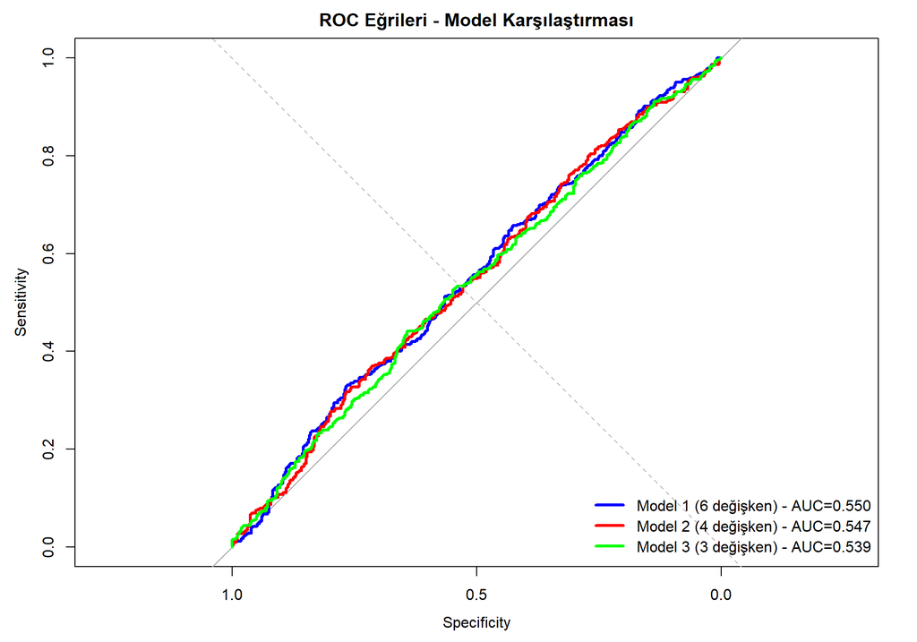

```r
# ROC eğrileri
roc1 <- roc(ogrenci_data$Cinsiyet, fitted(model1), quiet = TRUE)
roc2 <- roc(ogrenci_data$Cinsiyet, fitted(model2), quiet = TRUE)
roc3 <- roc(ogrenci_data$Cinsiyet, fitted(model3), quiet = TRUE)

# Görselleştirme
plot(roc1, col = "blue", lwd = 3, main = "ROC Eğrileri - Model Karşılaştırması")
lines(roc2, col = "red", lwd = 3)
lines(roc3, col = "green", lwd = 3)
abline(a = 0, b = 1, lty = 2, col = "gray")

legend("bottomright",
       legend = c(sprintf("Model 1 (6 değişken) - AUC=%.3f", auc(roc1)),
                  sprintf("Model 2 (4 değişken) - AUC=%.3f", auc(roc2)),
                  sprintf("Model 3 (3 değişken) - AUC=%.3f", auc(roc3))),
       col = c("blue", "red", "green"),
       lwd = 3,
       bty = "n")
```

## AUC Değerleri

```r
auc_df <- data.frame(
  Model = c("Model 1 (6 değişken)",
            "Model 2 (4 değişken)",
            "Model 3 (3 değişken)"),
  AUC = c(auc(roc1), auc(roc2), auc(roc3))
)

auc_df %>%
  arrange(desc(AUC)) %>%
  mutate(AUC = round(AUC, 4)) %>%
  kable(caption = "AUC Değerleri Sıralaması") %>%
  kable_styling(bootstrap_options = "striped", full_width = FALSE) %>%
  row_spec(1, bold = TRUE, background = "#d4edda")
```

AUC Değerleri Sıralaması

| Model | AUC |
| --- | --- |
| Model 1 (6 değişken) | 0.5503 |
| Model 2 (4 değişken) | 0.5469 |
| Model 3 (3 değişken) | 0.5394 |

# Sonuç ve Öneriler

## En İyi Model

**Önerilen Model:** Model 1 (6 Değişkenli Model)

### Model Değişkenleri:

1. Yas
2. Nabiz
3. Stress_Seviyesi_Biosensor
4. Fiziksel_Aktivite
5. Ruh_Hali
6. Proje_Saatleri

### Performans Metrikleri:

```r
final_metrics <- data.frame(
  Metrik = c("Accuracy", "AUC", "Nagelkerke R²", "AIC", "BIC"),
  Deger = c(
    sprintf("%.2f%%", accuracy1 * 100),
    sprintf("%.4f", auc(roc1)),
    sprintf("%.4f", r2_values1["Nagelkerke"]),
    sprintf("%.2f", AIC(model1)),
    sprintf("%.2f", BIC(model1))
  )
)

final_metrics %>%
  kable(caption = "Model 1 - Final Performans Metrikleri") %>%
  kable_styling(bootstrap_options = c("striped", "hover"), full_width = FALSE)
```

Model 1 - Final Performans Metrikleri

[output not shown]

## Öneriler

1. Hormon seviyeleri, genetik faktörler gibi biyolojik değişkenlerin eklenmesi
2. Alternatif makine öğrenmesi yöntemlerinin denenmesi (Random Forest, XGBoost)
3. Veri setinin genişletilmesi
4. Özellik mühendisliği ile yeni değişkenlerin türetilmesi

# Teknik Bilgiler

**Analiz Tarihi:** 2025-12-21  
**Yazar:** İbrahim Emin İpek  
**R Version:** R version 4.5.2 (2025-10-31 ucrt)